# Geographically Weighted Model

### Load dataset

For this model, we will use the following training and testing datasets:

- `prediction_dataset.csv`: For prediction purposes
- `regression_dataset.csv`: For training and regression purposes
- `vnm_.csv`: For constraints purposes

All data sets have been cleaned and contain no missing values.

For this model, mean radiance is transformed using
$$\ln(1+\text{mean_radiance})$$
in both the regression and prediction datasets to reduce the influence of extreme radiance values.

```r
# Regression Dataset
regression_data <- read.csv(file.path(data_dir, "training_data/regression_dataset.csv"))

# Prediction Dataset
prediction_data <- read.csv(file.path(data_dir, "training_data/prediction_dataset.csv"))

# National GDP totals used to constrain the regression fit
constrained_data <- read.csv(file.path(data_dir, "_vnm_indicators/vnm_level0_gdp.csv"))

# Provincial GRDP per-capita targets used to calibrate 2025 level-2 predictions
provincial_grdp_data <- read.csv(file.path(data_dir,
  "_vnm_indicators/vnm_GRDPpc.csv"),
  check.names = FALSE
)

# Provincial population totals (thousands) used as the aggregation constraint
provincial_population_data <- read.csv(file.path(data_dir,
  "_vnm_indicators/vnm_population.csv"),
  check.names = FALSE
)

# Provincial population data are in thousands; convert to persons.
regression_data$population <- regression_data$population * 1000
provincial_population_data[, as.character(2020:2025)] <-
  provincial_population_data[, as.character(2020:2025)] * 1000

# Change the mean_radiance into ln(1 + mean_radiance)
regression_data$mean_radiance <- log1p(
  regression_data$mean_radiance
)
prediction_data$mean_radiance <- log1p(
  prediction_data$mean_radiance
)
```

### Splitting the Training and Testing Sets

This setup performs the following tasks:

- Splits the data into a training set (2020–2024) and a holdout test set (2025).
- Selects `mean_radiance`, `population`, and `pixel_count` as the predictor variables.
- Standardizes the features in both the training and testing sets using the means and standard deviations calculated from the training data.
- Calculates the temporal extrapolation weights based on the training years

The temporal extrapolation weights is calculated as
$$w_t = \frac{1}{T}
+ \frac{(2025-\bar{t})(t-\bar{t})}
{\sum_{j=1}^{T}(t_j-\bar{t})^2}.$$

where

- $T = 5$: number of training years
- $t$: individual training years
- $\bar{t}$: mean training years

```r
model_data <- prepare_model_setup(regression_data)

X_train <- model_data$X_train
y_train <- model_data$y_train
X_test  <- model_data$X_test
y_test  <- model_data$y_test
temporal_weights = model_data$temporal_weights
training_data = model_data$training_data
holdout_data = model_data$holdout_data
training_sf = model_data$training_sf
holdout_sf = model_data$holdout_sf
training_years = model_data$training_years
holdout_year = model_data$holdout_year
y_train_raw = model_data$y_train_raw
y_test_raw = model_data$y_test_raw
feature_columns = model_data$feature_columns
feature_means = model_data$feature_means
feature_sds = model_data$feature_sds
response_mean = model_data$response_mean
response_sd = model_data$response_sd
```

### Prepare OLS references

Ordinary Least Squares (OLS) is used as a baseline reference model to evaluate predictions on both the training and holdout sets (2025). It also provides baseline performance metrics, including $R^2$ and RMSE, for comparison with more advanced models.

```r
ols_comparison <- fit_ols_comparison(model_data)

ols_coefficients <- ols_comparison$coefficients
ols_training_predictions <- ols_comparison$training
ols_holdout_predictions <- ols_comparison$holdout
ols_metrics <- ols_comparison$metrics
ols_training_predictions <- ols_comparison$training$predicted
ols_holdout_predictions <- ols_comparison$holdout$predicted
```

### Preliminaries

Supposed:

- $y \in \mathbb{R}^n$: observed outcome vector. That is, `grdp_per_capita`.
- $x_i \in \mathbb{R}^3$: standardized explanatory variables for observation $i$: `mean_radiance`, `population`, and `pixel_count`.
- $s_i \in \mathbb{R}^2$: geographic coordinates (longitude and latitude) representing the centroid of observation $i$.
- $\alpha_t(s) \in \mathbb{R}$: locally estimated year-specific intercept for year $t$ at geographic location $s$.
- $\beta(s) \in \mathbb{R}^3$: locally estimated slopes for the three explanatory variables at geographic location $s$.
- $w_i(s) \in [0,1]$: spatial weight assigned to observation $i$ when estimating the model at location $s$, determined by great-circle distance and an adaptive bisquare kernel.
- $h$: adaptive bandwidth, representing the number of nearest training observations used to determine spatial weights.

The model estimates geographically varying year-specific intercepts and explanatory-variable coefficients using locally weighted least squares.

#### Adaptive bisquare spatial weighting

Spatial weights are determined using an adaptive bisquare kernel based on great-circle distances between geographic coordinates.

For a target location $s$, let $d_i(s)$ denote the great-circle distance between observation $i$ and the target location. The adaptive bandwidth $b(s)$ is defined as the distance to the $h$-th nearest training observation. The spatial weight is then calculated as:

$$w_i(s) =
\begin{cases}
\left[1-\left(\dfrac{d_i(s)}{b(s)}\right)^2\right]^2,
& \text{if } d_i(s) < b(s), \\[8pt]
0,
& \text{if } d_i(s) \geq b(s).
\end{cases}$$
which is the bisquare kernel.

This weighting scheme has the following properties:

1. Nearby observations receive greater weights. Observations closer to the target location have weights closer to one, giving them greater influence on the local coefficient estimates.
2. Weights decrease smoothly with distance. As the distance approaches the adaptive bandwidth, the weight gradually decreases toward zero. This avoids an abrupt change in influence among observations within the local neighborhood.
3. Distant observations receive zero weight. Observations outside the adaptive bandwidth do not contribute to the local estimation.
4. The geographic bandwidth adapts to local observation density. The number of nearest neighbors remains approximately controlled by $h$, while the corresponding geographic radius varies across locations.

To select the adaptive bandwidth, candidate nearest-neighbor counts are derived from fractions $[0.01, 0.99]$ of the training sample size. Each candidate is constrained to have at least $p+2$ neighbors, where $p$ is the number of estimated local coefficients, and no more than the total number of training observations. This provides a range of neighborhood sizes that can be evaluated while avoiding neighborhoods that are too small for stable local estimation.

```r
bandwidth_fractions <- seq(0.01,0.99, length.out = 97)
bandwidth_grid <- bandwidth_fractions |>
  (\(x) ceiling(x * nrow(training_data)))() |>
  pmax(ncol(X_train) + 2) |>
  pmin(nrow(training_data)) |>
  unique()
kernel_name <- "bisquare"
```

We then compute the distances between training and holdout observations, distances between training observations, and the bandwidth weight matrix

```r
#gw.dist: gw distant

# holdout_distances: distances between training and holdout data
holdout_distances <- t(gw.dist(
  dp.locat = training_data[, c("longitude", "latitude")] |> data.matrix(),
  rp.locat = holdout_data[, c("longitude", "latitude")] |> data.matrix(),
  longlat = TRUE
))

# training_distances: distances between training data
training_distances <- t(gw.dist(
  dp.locat = training_data[, c("longitude", "latitude")] |> data.matrix(),
  longlat = TRUE
))

# holdout_weights: weight matrix for every candidate bandwidth
holdout_weights <- lapply(bandwidth_grid, function(bandwidth) {
  gw.weight(
    holdout_distances,
    bw = bandwidth,
    kernel = kernel_name,
    adaptive = TRUE
  )
})
```

### Model estimations

The Geographically weighted model is given as

$$y_i = \alpha(s_i) + \sum_{j=1}^{3} \beta_j(s_i)x_{ij} + \epsilon_i$$

The model is fitted using the 2020–2024 training data with the shared standardized response and design matrix.

```r
# Initialize storage for model results

# training_predictions: predictions on training data
training_predictions <- matrix(
  NA_real_,
  nrow = nrow(training_data),
  ncol = length(bandwidth_grid)
)

# holdout_predictions: predictions on testing data
holdout_predictions <- matrix(
  NA_real_,
  nrow = nrow(holdout_data),
  ncol = length(bandwidth_grid)
)
```

```r
# model_formula: model specification
model_formula <- grdp_per_capita ~ year_2020 + year_2021 + year_2022 + year_2023 + year_2024 + mean_radiance_scaled + population_scaled + pixel_count_scaled - 1

# Evaluate each candidate bandwidth using GW model
for (bandwidth_index in seq_along(bandwidth_grid)) {
  training_fit <- gwr.predict(
    model_formula,
    data = training_sf,
    predictdata = training_sf,
    bw = bandwidth_grid[bandwidth_index],
    kernel = kernel_name,
    adaptive = TRUE,
    longlat = TRUE,
    dMat1 = training_distances,
    dMat2 = training_distances
  )
  training_predictions[, bandwidth_index] <-
    training_fit$SDF$prediction * response_sd + response_mean

  holdout_fit <- gwr.predict(
    model_formula,
    data = training_sf,
    predictdata = holdout_sf,
    bw = bandwidth_grid[bandwidth_index],
    kernel = kernel_name,
    adaptive = TRUE,
    longlat = TRUE,
    dMat1 = holdout_distances,
    dMat2 = training_distances
  )
  holdout_predictions[, bandwidth_index] <-
    holdout_fit$SDF$prediction * response_sd + response_mean
}
```

### Model Evaluation and Hyperparameter Selection

For each data split, the mean and total sum of squares (SST) are calculated using the observed GRDP-per-capita values within that split. We evaluate model performance using the following metrics.

The coefficient of determination ($R^2$) is calculated for each model as

$$R^2
= 1-\frac{\sum_{i=1}^{n}(y_i-\hat y_i)^2}{\mathrm{SST}},$$

where

$$\bar y = \frac{1}{n}\sum_{i=1}^{n} y_i,
\qquad
\mathrm{SST} = \sum_{i=1}^{n}(y_i-\bar y)^2.$$

We also calculate the root mean squared error (RMSE), expressed in the original GRDP-per-capita units, as

$$\mathrm{RMSE}
=\sqrt{\frac{1}{n}\sum_{i=1}^{n}(y_i-\hat y_i)^2}.$$

```r
# Prepare diagnostics.
training_diagnostics <- lapply(seq_along(bandwidth_grid), function(bandwidth_index) {
  prepare_model_diagnostics(
    data = training_data,
    fitted = training_predictions[, bandwidth_index],
    model_name = "GW Model",
  )
})

holdout_diagnostics <- lapply(seq_along(bandwidth_grid), function(bandwidth_index) {
  prepare_model_diagnostics(
    data = holdout_data,
    fitted = holdout_predictions[, bandwidth_index],
    model_name = "GW Model",
  )
})

bandwidth_results <- data.frame(
  bandwidth = bandwidth_grid,

  # Training diagnostics
  training_RMSE = sapply(training_diagnostics, function(x) {
    x$metrics$RMSE
  }),
  training_R_squared = sapply(training_diagnostics, function(x) {
    x$metrics$R_squared
  }),

  # Holdout diagnostics
  holdout_RMSE = sapply(holdout_diagnostics, function(x) {
    x$metrics$RMSE
  }),
  holdout_R_squared = sapply(holdout_diagnostics, function(x) {
    x$metrics$R_squared
  })
)

# Save
write.csv(
  bandwidth_results,
  file.path(data_output_dir, "gw_model_bandwidth_grid_diagnostic_metrics.csv"),
  row.names = FALSE
)
```

We select the optimal bandwidth from the candidate grid based on the holdout performance, aiming to minimize RMSE and maximize $R^2$.

```r
# Select the bandwidth that minimizes the 2025 holdout RMSE.
selected_index <- which.min(bandwidth_results$holdout_RMSE)
selected_bandwidth <- bandwidth_results$bandwidth[selected_index]

# Get training and holdout diagnostics of selected bandwidth.
opt_training_diagnostics <- prepare_model_diagnostics(
  training_data,
  training_predictions[, selected_index],
  ols_training_predictions,
  "GW Model",
  "OLS"
)
opt_holdout_diagnostics <- prepare_model_diagnostics(
  holdout_data,
  holdout_predictions[, selected_index],
  ols_holdout_predictions,
  "GW Model",
  "OLS"
)

# Report the selected bandwidth and evaluation metrics.
cat("Selected bandwidth by minimum 2025 holdout RMSE: ")
```

```
## Selected bandwidth by minimum 2025 holdout RMSE:
```

```r
print(selected_bandwidth)
```

```
## [1] 91
```

```r
# Save
write.csv(
  opt_training_diagnostics$diagnostics,
  file.path(data_output_dir, "gw_model_training_diagnostics.csv"),
  row.names = FALSE
)
write.csv(
  opt_holdout_diagnostics$diagnostics,
  file.path(data_output_dir, "gw_model_holdout_diagnostics.csv"),
  row.names = FALSE
)
model_comparison_metrics <- bind_rows(
  Training = opt_training_diagnostics$metrics,
  Holdout = opt_holdout_diagnostics$metrics,
  .id = "Dataset"
)
write.csv(
  model_comparison_metrics,
  file.path(data_output_dir, "gw_model_comparison_metrics.csv"),
  row.names = FALSE
)
```

#### Bandwidth sensitivity analysis

The vertical line and highlighted point mark the selected bandwidth.

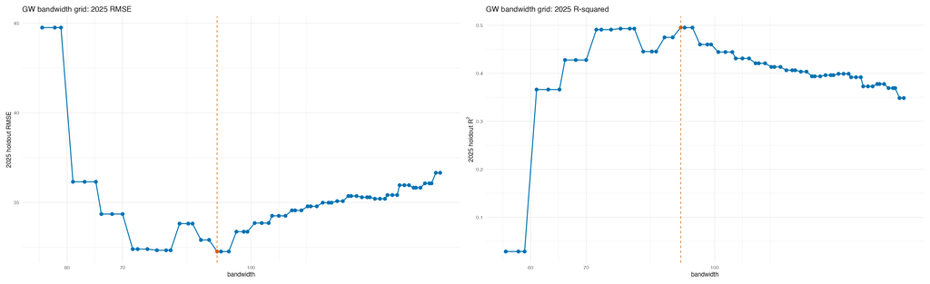

```r
gw_bandwidth_metrics_plot <- plot_gw_bandwidth_metrics(
  bandwidth_results |> filter(holdout_R_squared > 0),
  selected_bandwidth
)

# Save and display
gw_bandwidth_metrics_path <- file.path(
  figure_output_dir,
  "gw_bandwidth_grid_metrics.png"
)
ggsave(
  gw_bandwidth_metrics_path,
  gw_bandwidth_metrics_plot,
  width = 22.5,
  height = 6.875,
  dpi = 160
)

knitr::include_graphics(gw_bandwidth_metrics_path)
```

### Residual Diagnostics

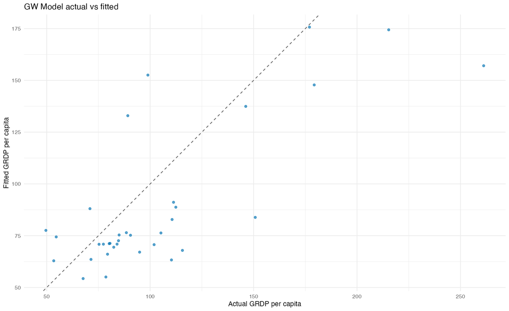

```r
# Plot holdout actual vs fitted.
holdout_actual_fitted_plot <- plot_actual_vs_fitted(
  holdout_data,
  holdout_predictions[, selected_index],
  "GW Model"
)

# Save and display
holdout_actual_fitted_path <- file.path(
  figure_output_dir,
  "gw_model_holdout_actual_vs_fitted.png"
)
ggsave(
  holdout_actual_fitted_path,
  holdout_actual_fitted_plot,
  width = 11.25,
  height = 6.875,
  dpi = 160
)

knitr::include_graphics(holdout_actual_fitted_path)
```

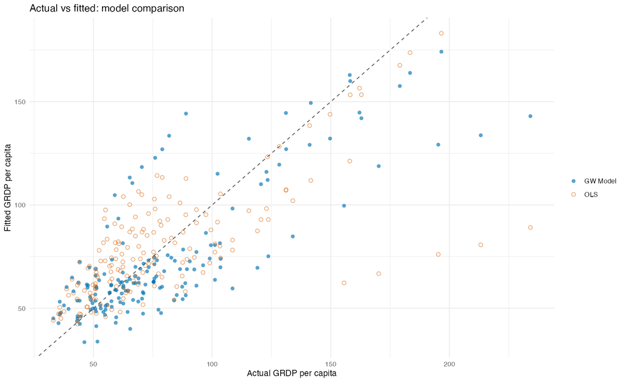

```r
training_model_comparison_plot <- plot_model_comparison(
  training_data,
  training_predictions[, selected_index],
  ols_training_predictions,
  "GW Model",
  "OLS"
)

# Save and display
training_comparison_path <- file.path(
  figure_output_dir,
  "gw_model_training_actual_vs_fitted_comparison.png"
)
ggsave(
  training_comparison_path,
  training_model_comparison_plot,
  width = 11.25,
  height = 6.875,
  dpi = 160
)

knitr::include_graphics(training_comparison_path)
```

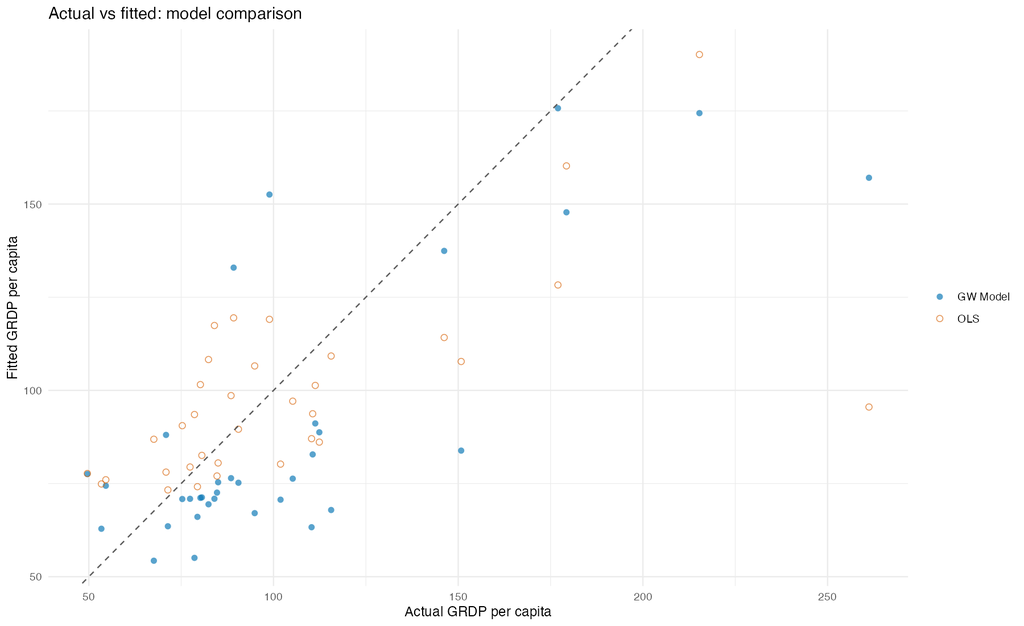

```r
holdout_model_comparison_plot <- plot_model_comparison(
  holdout_data,
  holdout_predictions[, selected_index],
  ols_holdout_predictions,
  "GW Model",
  "OLS"
)

# Save and display
holdout_comparison_path <- file.path(
  figure_output_dir,
  "gw_model_holdout_actual_vs_fitted_comparison.png"
)
ggsave(
  holdout_comparison_path,
  holdout_model_comparison_plot,
  width = 11.25,
  height = 6.875,
  dpi = 160
)

knitr::include_graphics(holdout_comparison_path)
```

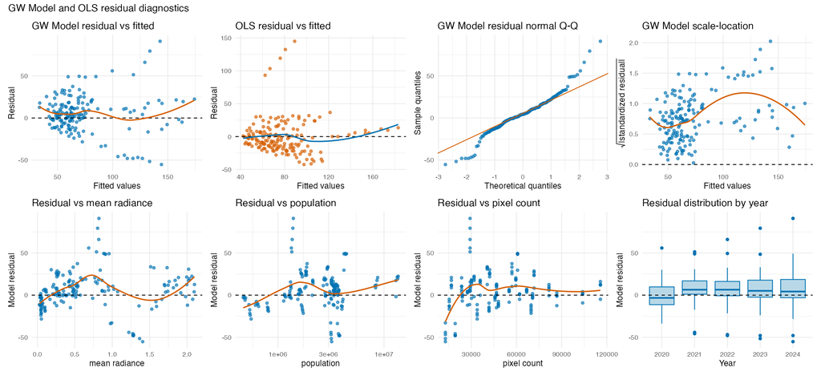

```r
# Plot training diagnostic plots.
training_plots <- plot_residual_diagnostics(
  opt_training_diagnostics$diagnostics,
  "GW Model",
  "OLS"
)

# Save and display
training_diagnostics_path <- file.path(
  figure_output_dir,
  "gw_model_training_residual_diagnostics.png"
)
ggsave(
  training_diagnostics_path,
  training_plots$combined,
  width = 15,
  height = 6.875,
  dpi = 160
)

knitr::include_graphics(training_diagnostics_path)
```

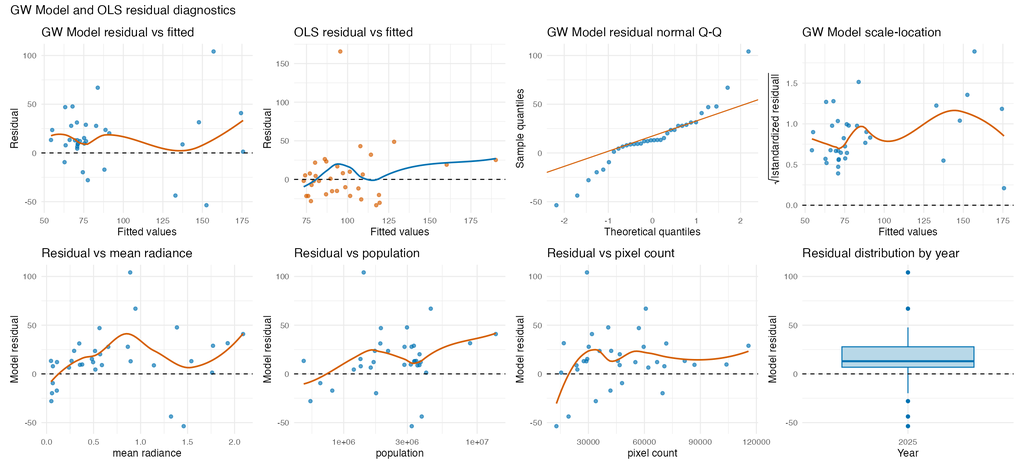

```r
# Plot holdout diagnostic plots.
holdout_plots <- plot_residual_diagnostics(
  opt_holdout_diagnostics$diagnostics,
  "GW Model",
  "OLS"
)

# Save and display
holdout_diagnostics_path <- file.path(
  figure_output_dir,
  "gw_model_holdout_residual_diagnostics.png"
)
ggsave(
  holdout_diagnostics_path,
  holdout_plots$combined,
  width = 15,
  height = 6.875,
  dpi = 160
)

knitr::include_graphics(holdout_diagnostics_path)
```

### Training using all data

Prepare the complete dataset for the full optimization model. All observations are used to standardize the predictor variables and response variable.

```r
full_model_data <- prepare_full_model_setup(regression_data)
X <- full_model_data$X
y <- full_model_data$y
years <- full_model_data$years

regression_sf <- full_model_data$regression_sf
feature_columns <- full_model_data$feature_columns
feature_means <- full_model_data$feature_means
feature_sds <- full_model_data$feature_sds
response_mean <- full_model_data$response_mean
response_sd <- full_model_data$response_sd
```

Fit the GW model using all available years.

```r
# model_formula: model specification
model_formula <- grdp_per_capita ~ year_2020 + year_2021 + year_2022 + year_2023 + year_2024 + year_2025 + mean_radiance_scaled + population_scaled + pixel_count_scaled - 1

# distances: distances between data
distances <- t(gw.dist(
  dp.locat = regression_data[, c("longitude", "latitude")] |> data.matrix(),
  longlat = TRUE
))

# weights: weight matrix for every candidate bandwidth
weights <- gw.weight(
  distances,
  bw = selected_bandwidth,
  kernel = kernel_name,
  adaptive = TRUE
)

# Save fitted model
fitted_model <- local({
  variable_names <- colnames(X)
  training_years <- years
  training_data <- regression_sf

  list(
    model = gwr.predict(
      model_formula,
      data = regression_sf,
      predictdata = regression_sf,
      bw = selected_bandwidth,
      kernel = kernel_name,
      adaptive = TRUE,
      longlat = TRUE
    ),
    variable_names = variable_names,
    years = training_years,
    feature_columns = feature_columns,
    feature_means = feature_means,
    feature_sds = feature_sds,
    response_mean = response_mean,
    response_sd = response_sd,

    predict = function(newdata) {

      # Calculate temporal extrapolation weights.
      T <- length(training_years)
      time_index <- seq_len(T)
      time_mean <- mean(time_index)

      target_index <- newdata$year - min(training_years) + 1

      temporal_weights <- sapply(target_index, function(t_star) {
        1 / T +
          (t_star - time_mean) *
          (time_index - time_mean) /
          sum((time_index - time_mean)^2)
      })

      # Standardize prediction features.
      scaled_features <- as.matrix(newdata[feature_columns])

      scaled_features <- sweep(
        scaled_features, 2,
        feature_means[feature_columns], "-"
      )

      scaled_features <- sweep(
        scaled_features, 2,
        feature_sds[feature_columns], "/"
      )

      # Construct prediction matrix.
      prediction_X <- cbind(
        t(temporal_weights),
        scaled_features
      )

      colnames(prediction_X) <- variable_names

      # Construct prediction data.
      prediction_sf <- st_as_sf(
        data.frame(
          prediction_X,
          longitude = newdata$longitude,
          latitude = newdata$latitude
        ),
        coords = c("longitude", "latitude"),
        crs = 4326,
        remove = FALSE
      )

      # Distance matrix between training and prediction locations.
      newdata_distances <- t(gw.dist(
        dp.locat = regression_data[, c("longitude", "latitude")] |> data.matrix(),
        rp.locat = prediction_data[, c("longitude", "latitude")] |> data.matrix(),
        longlat = TRUE
      ))

      # Predict at new locations.
      prediction <- gwr.predict(
        model_formula,
        data = regression_sf,
        predictdata = prediction_sf,
        bw = selected_bandwidth,
        kernel = kernel_name,
        adaptive = TRUE,
        longlat = TRUE,
        dMat1 = newdata_distances,
        dMat2 = distances
      )

      raw_predictions = prediction$SDF$prediction * response_sd + response_mean

      return (raw_predictions)
    }
  )
})

model_path = file.path(model_output_dir, "gw_model.rds")
saveRDS(fitted_model, model_path)
```

### 2025 Level-2 Predictions

Using the trained model from the previous section, we first predicts GRDP per capita for each level-2 unit using the 2025 intercept and the same means and standard deviations used to standardize the training data.

```r
# Setting up prediction data
level2_prediction_data <- prepare_prediction_data(
  prediction_data = prediction_data,
  provincial_grdp_data = provincial_grdp_data,
  provincial_population_data = provincial_population_data,
  feature_columns = feature_columns,
  feature_means = feature_means,
  feature_sds = feature_sds
)
```

The raw prediction is
$$\hat{y}_{i,2025}^{\text{GWR}}
=
\sum_{t=1}^{T} w_t \hat{\alpha}_{t,i}
+
\sum_{m=1}^{p} \hat{\beta}_{m,i} X_{mi,2025}$$

```r
# Make raw prediction
raw_predictions <- fitted_model$predict(level2_prediction_data)
level2_prediction_data$raw_predictions <- raw_predictions
```

Next, we adjust these predictions so that their population weighted total matches the province’s reported 2025 GRDP per capita multiplied by its total population.

#### Adjustment Solution 1: Additive adjustment

To do this, we add the same adjustment $\delta_j$ to every level-2 prediction within province $j$:

$$\tilde y_{ij} = \hat y_{ij} + \delta_j$$

The adjustment is calculated as:

$$\delta_j = \frac{g_j\sum_{i\in
j}P_{ij}-\sum_{i\in j}P_{ij}\hat y_{ij}} {\sum_{i\in j}P_{ij}}$$

where $g_j$ is the province’s reported GRDP per capita and $P_{ij}$ is the population of level-2 unit $i$.

```r
# Adjustment Solution 1: Additive adjustment
calculate_additive_adjustments <- function(level2_prediction_data) {

  province_groups <- split(
    seq_len(nrow(level2_prediction_data)),
    level2_prediction_data$level_1
  )

  vapply(province_groups, function(idx) {

    population <- level2_prediction_data$population[idx]

    level2_prediction_data$grdp_pc_2025[idx[1]] -
      weighted.mean(
        level2_prediction_data$raw_predictions[idx],
        population
      )

  }, numeric(1))
}

# Apply additive adjustment
additive_adjustments <- calculate_additive_adjustments(
  level2_prediction_data
)

level2_prediction_data$additive_adjustment <-
  unname(additive_adjustments[level2_prediction_data$level_1])

level2_prediction_data$additive_predictions <-
  level2_prediction_data$raw_predictions +
  level2_prediction_data$additive_adjustment
```

#### Adjustment Solution 2: Proportional scaling

Another approach is to adjust the level-2 predictions by multiplying every prediction within province $j$ by a common scaling factor:

$$s_j = \frac{g_j}{\bar{y}_j},$$

where

$$\bar{y}_j = \frac{\sum_{i=1}^{n_j}
P_{ij}\hat{y}_{ij}} {\sum_{i=1}^{n_j} P_{ij}}$$

is the population-weighted average of the raw level-2 predictions in province $j$. The adjusted prediction for each level-2 unit is then:

$$\tilde {y}_{ij}=s_j\hat{y}_{ij}.$$

```r
# Adjustment Solution 2: Proportional scaling
calculate_scaling_adjustments <- function(level2_prediction_data) {
  province_groups <- split(
    seq_len(nrow(level2_prediction_data)),
    level2_prediction_data$level_1
  )

  vapply(province_groups, function(idx) {

    population <- level2_prediction_data$population[idx]

    predicted_mean <- weighted.mean(
      level2_prediction_data$raw_predictions[idx],
      population
    )

    level2_prediction_data$grdp_pc_2025[idx[1]] /
      predicted_mean

  }, numeric(1))
}

# Apply proportional scaling
scaling_adjustments <- calculate_scaling_adjustments(level2_prediction_data)

level2_prediction_data$scaling_adjustments <-
  unname(scaling_adjustments[level2_prediction_data$level_1])

level2_prediction_data$scaled_predictions <-
  level2_prediction_data$raw_predictions *
  level2_prediction_data$scaling_adjustments
```

```r
# Save prediction results
prediction_output <- file.path(
  data_output_dir,
  "gw_model_level2_predictions.csv"
)

write.csv(
  level2_prediction_data,
  prediction_output,
  row.names = FALSE
)
```